# Tablas y Gráficas

Estadística Descriptiva

9 de octubre de 2020

# Gráficos Estadísticos

Una vez que hayan sido recolectados los datos muestrales, debemos “conocerlos”. Una de las formas más útiles de conocer los datos es usar una técnica inicial de exploración de análisis de datos que resultará en una representación gráfica de los datos. La gráfica revelará visualmente patrones de comportamiento de la variable bajo estudio. Hay diversas formas gráfi as de describir datos. El tipo de datos y la idea que se va representar determina el método que se va a utilizar.

## Diagrama de Tallos y Hojas

El diagrama “tallo y hojas” (**Stem-and-Leaf Diagram**) permite obtener simultáneamente una distribución de frecuencias de la variable y su representación gráfica. presenta los datos de una muestra usando los dígitos reales que conforman el dato. Cada valor numérico se divide en dos partes: El dígito o dígitos principales son el **tallo**, y los dígitos que le siguen son las **hojas**.

Supogamos la siguiente muestra con las edades de 20 personas:

```r
edades_personas <- c(36, 25, 37, 24, 39, 20, 36, 45, 31, 31,
                     39, 24, 29, 23, 41, 40, 33, 24, 34, 40)
```

Vamos a representar estos datos mediante un diagrama de Tallos y Hojas.

Comenzamos seleccionando los **tallos**, que en nuestro caso son las cifras de decenas, es decir 3, 2, 4, que reordenadas son 2, 3 y 4.

A continuación efectuamos un recuento y vamos «añadiendo» cada **hoja** a su **tallo** y de esa manera obtenemos el siguiente diagrama:

| Tallos | Hojas |
| --- | --- |
| 2 | 5 4 0 4 9 3 4 |
| 3 | 6 7 9 6 1 1 9 3 4 |
| 4 | 5 1 0 0 |

Por último reordenamos las hojas y hemos terminado el diagrama:

| Tallos | Hojas |
| --- | --- |
| 2 | 0 3 4 4 4 5 9 |
| 3 | 1 1 3 4 6 6 7 9 9 |
| 4 | 0 0 1 5 |

Podemos lograr esta solución igualmente utilizando la operación `stem` de R tal como lo muestra el siguiente fragmento de código:

```r
# Diagrama de Tallos y Hojas de las edades
stem(edades_personas)
```

```
##
##   The decimal point is 1 digit(s) to the right of the |
##
##   2 | 0344459
##   3 | 113466799
##   4 | 0015
```

## Histogramas

Una forma común de presentación gráfica son los **histogramas**, que son gráficas de barras en las que se usa un plano cartesiano (un plano con un eje vertical, que corresponde al eje de las y y un eje horizontal, el del eje de las x). En este plano se utiliza el eje horizontal para medir la variable y el eje vertical para medir la frecuencia, sea absoluta o relativa.

Si la variable es cuantitativa, podemos utilizar la operación de R llamada `hist()` para obtener el gráfico de barras con la frecuencia de los datos.

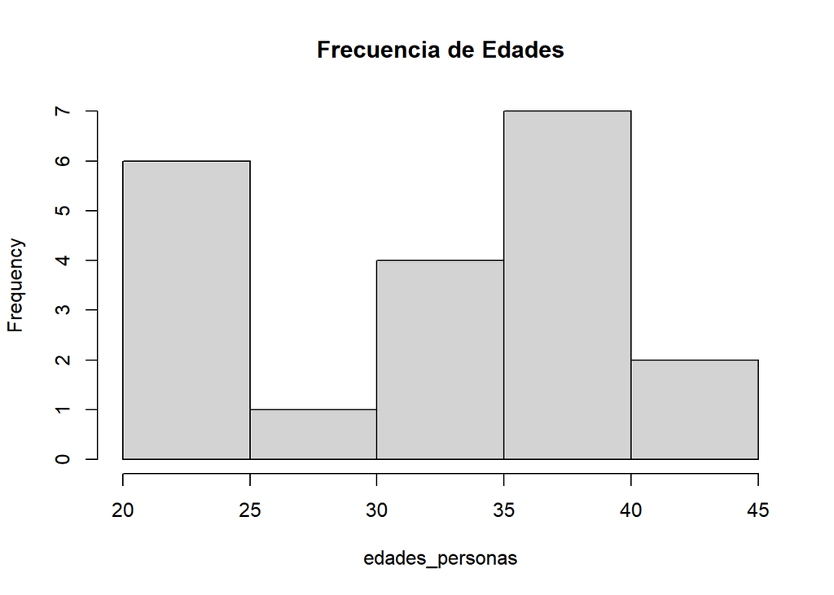

```r
hist(edades_personas, main = "Frecuencia de Edades")
```

Se pueden especificar para este diagrama opciones de formato como el color, pero también se puede especificar el número mínimo de grupos en que vamos a dividir a los datos, tal como se muestra a continuación:

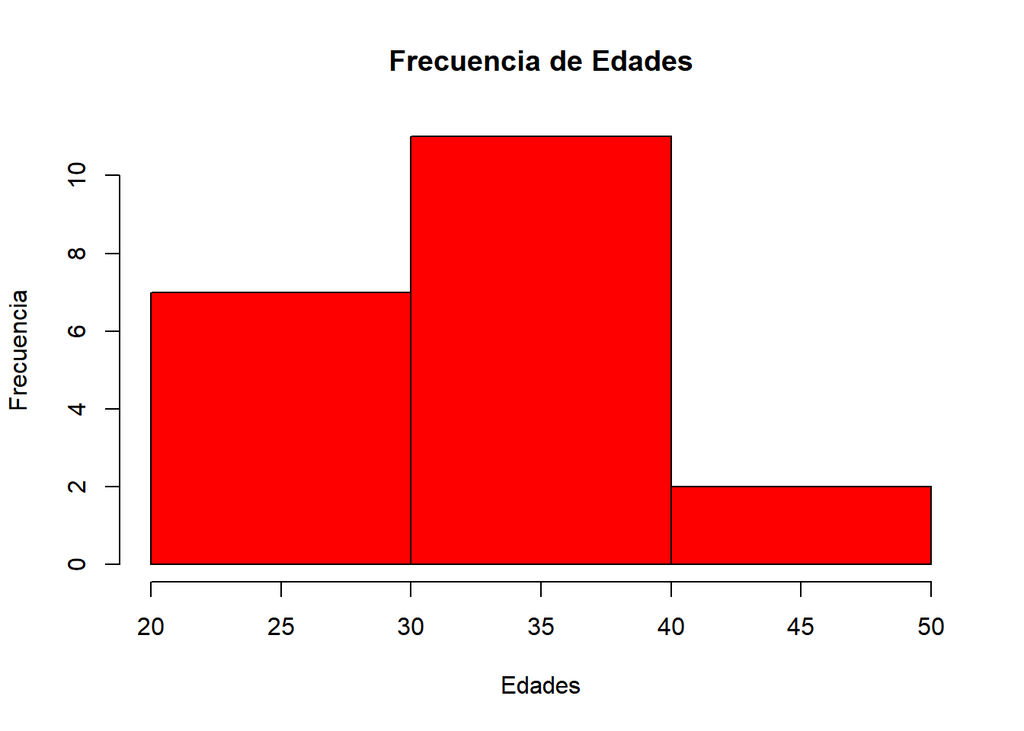

```r
hist(edades_personas, main = "Frecuencia de Edades", xlab = "Edades",
     ylab = "Frecuencia", col = "red", breaks = 3)
```

### Obtener datos del histograma

Si almacenamos el histograma en un objeto, podemos utilizar ese objeto para obtener información acerca del histograma, tal como se muestra a continuación:

```r
h <- hist(edades_personas, breaks = 3, plot = FALSE)
```

Podemos, por ejemplo, obtener el límite inferior de cada grupo:

```r
h$breaks
```

```
## [1] 20 30 40 50
```

También podemos obtener la cantidad de datos que hay en cada uno de los grupos:

```r
h$counts
```

```
## [1]  7 11  2
```

Y finalmente, podemos obtener el punto medio de cada intervalos de la siguiente forma:

```r
h$mids
```

```
## [1] 25 35 45
```

## Polígono de frecuencia

Polígono de frecuencia es el nombre que recibe una clase de gráfico que se crea a partir de un **histograma de frecuencia**. El **polígono de frecuencia** es realizado uniendo los puntos de mayor altura de estas columnas.

Para lograr este gráfico en R debemos dibujar una línea extra en el histograma de manera que se pueda ver el polígono. El codigo a continuación nos muestra la manera de hacerlo:

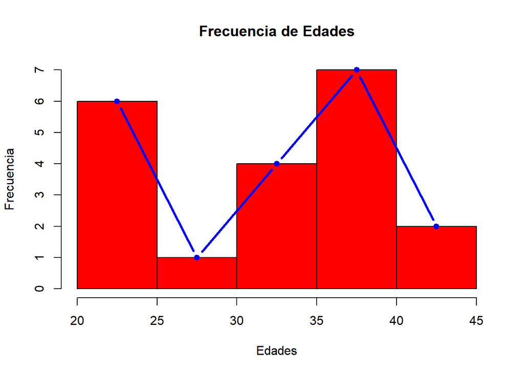

```r
# Primero dibujamos el histograma con las frecuencias de las edades
h <- hist(edades_personas, col = "red", main = "Frecuencia de Edades", xlab = "Edades",
     ylab = "Frecuencia")
# Y luego las líneas que une los puntos medios de cada barra
x <- h$mids
y <- h$counts
lines(x, y, col = "blue", type="b", pch = 20, lwd = 3)
```

### El paquete agricolae

Una forma más fácil de crear tablas de frecuencias, así como histogramas y polígonos de frecuencia es a través del paquete `agricolae`:

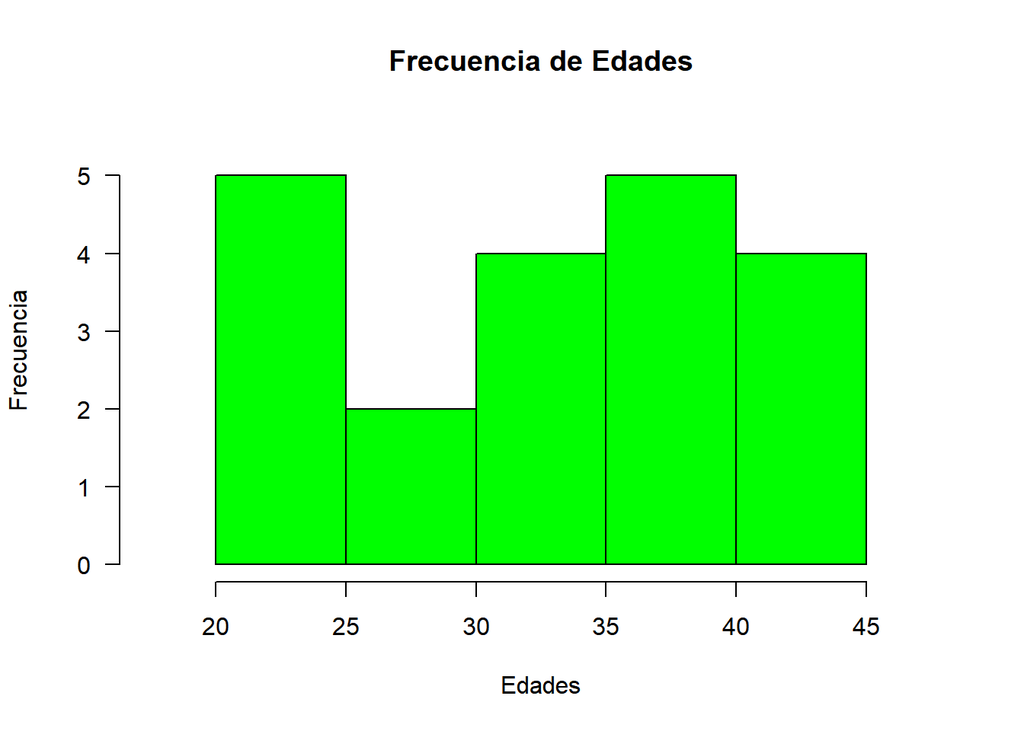

```r
library(agricolae)

# Creamos el histograma de grecuencias de las edades
histo <- graph.freq(edades_personas, col = "green",
                    main = "Frecuencia de Edades",
                    xlab = "Edades", ylab = "Frecuencia")
```

Una vez tenemos el histograma, podemos mostrar la tabla de frecuencia de la cual se derivó el histograma, utilizando la siguiente operación:

```r
knitr::kable(summary(histo))
```

| Lower | Upper | Main | Frequency | Percentage | CF | CPF |
| --- | --- | --- | --- | --- | --- | --- |
| 20 | 25 | 22.5 | 5 | 25 | 5 | 25 |
| 25 | 30 | 27.5 | 2 | 10 | 7 | 35 |
| 30 | 35 | 32.5 | 4 | 20 | 11 | 55 |
| 35 | 40 | 37.5 | 5 | 25 | 16 | 80 |
| 40 | 45 | 42.5 | 4 | 20 | 20 | 100 |

Y también podemos dibujar el polígono de frecuencia muy facilmente si ya tenemos guardado el histograma en algún objeto utilizando la operación `polygon.freq`:

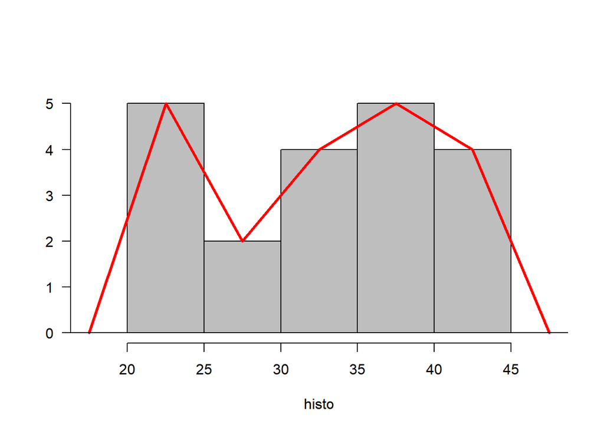

```r
plot(histo, col = "gray")
polygon.freq(histo, col = "red", lwd = 3)
```

## Ojivas

También se denomina **Polígono de frecuencia acumulada**. Se trata de una gráfica de línea de frecuencia absoluta acumulada de los datos, aunque también se puede hacer de la frecuencia relativa acumulada.

Si ya tenemos un histograma construido con `hist`, podemos crear esta **Ojiva** o polígono de frecuencia acumulada utilizando el siguiente fragmento de código:

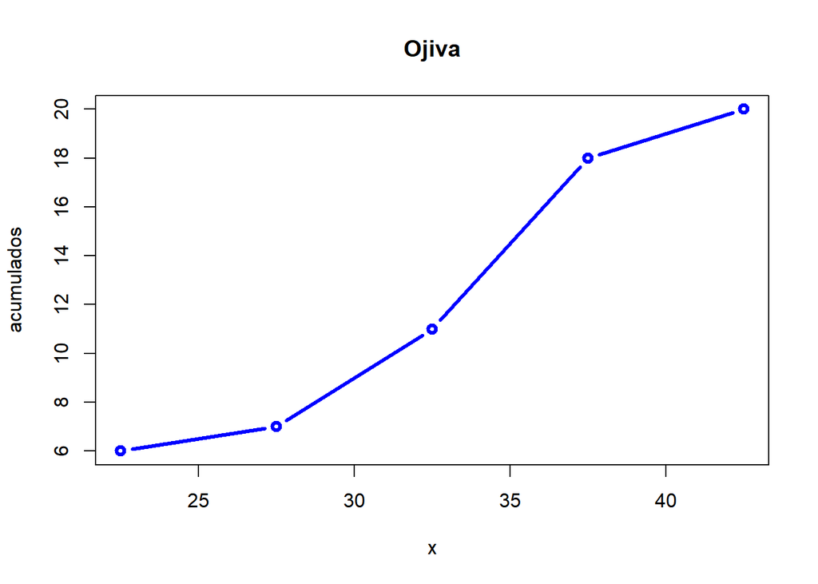

```r
# Hallamos la frecuencia absoluta acumulada del histograma h
acumulados <- cumsum(h$counts)
# Y ahora dibujamos la línea entre los puntos
plot(x, acumulados, type = "b", col = "blue", lwd = 3, main = "Ojiva")
```

Auque podemos hacer lo mismo más fácilmente utilizando el paquete `agricolae` tal como se muestra en el siguiente fragmento de código:

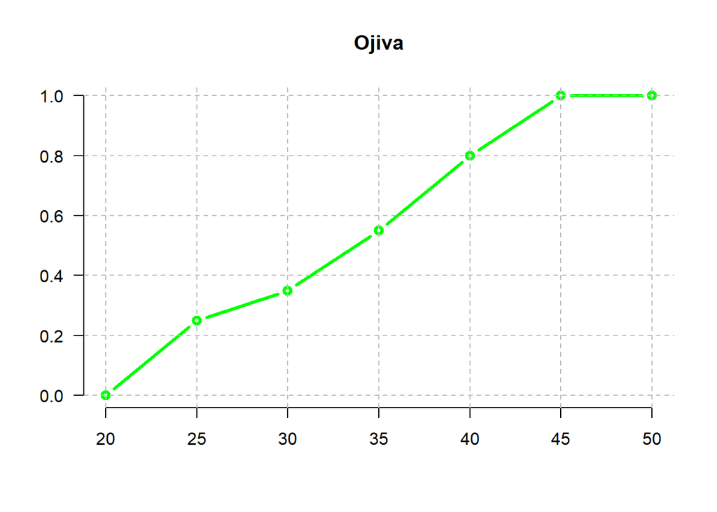

```
##    x  RCF
## 1 20 0.00
## 2 25 0.25
## 3 30 0.35
## 4 35 0.55
## 5 40 0.80
## 6 45 1.00
## 7 50 1.00
```

```r
ogive.freq(histo, type = "b", col = "green", main = "Ojiva", lwd = 3)
```

## Diagramas de Pareto

una gráfica especial de barras. En ésta, las barras se presentan de la categoría más numerosa a la menos numerosa. Incluye una gráfica de líneas que muestra los porcentajes acumulativos y las cantidades para las barras.

Para hacer este gráfico, vamos a utilizar la operación `pareto.chart` del paquete `qcc`. El siguiente fragmento de código nos presenta la manera de hacer este gráfico:

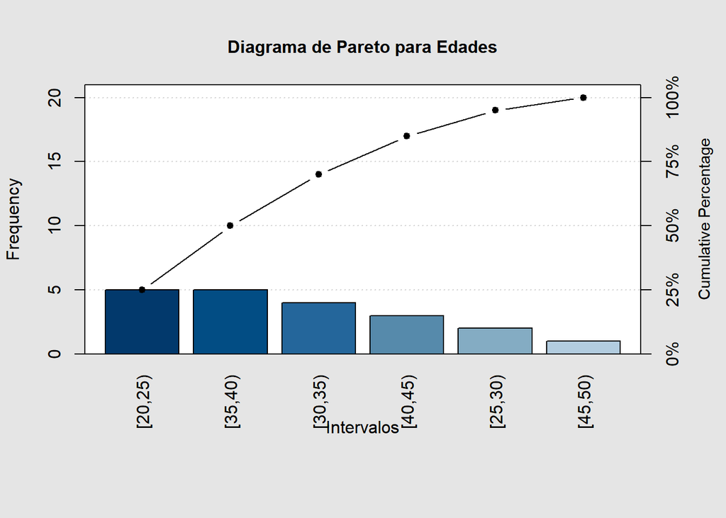

```
##
## Pareto chart analysis for tabla
##           Frequency Cum.Freq. Percentage Cum.Percent.
##   [20,25)         5         5         25           25
##   [35,40)         5        10         25           50
##   [30,35)         4        14         20           70
##   [40,45)         3        17         15           85
##   [25,30)         2        19         10           95
##   [45,50)         1        20          5          100
```

```r
library(qcc)

# Armamos la tabla de distribución de frecuencia por grupos para las edades
grupos <- seq(20, 50, by = 5)  # Amplitud = 5
cortes <- cut(edades_personas, grupos, right = F)
tabla <- table(cortes)

# Y ahora presentamos el gráfico de Pareto
pareto.chart(tabla, main = "Diagrama de Pareto para Edades", xlab = "Intervalos")
```

## Gráfico de Torta

Las gráficas de torta (diagramas de pastel) muestran la cantidad de datos que pertenecen a cada una de las categorías como parte proporcional de un círculo.

Los gráficos de torta o *pie charts* son creados con la operación **pie(datos, labels=)** donde los datos son un vector de números positivos indicando el área de cada porción de la torta y **labels=** es el vector de etiquetas o nombre de cada porción.

### Un gráfico de torta sencillos

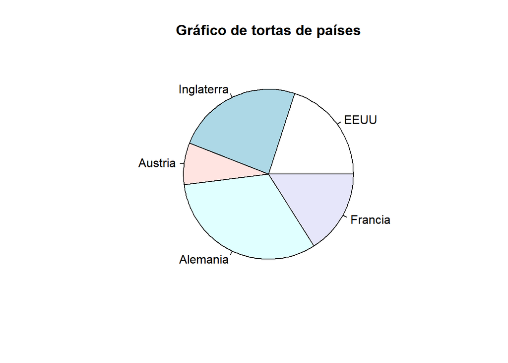

```r
# Estos son los datos a presentar
datos <- c(10, 12, 4, 16, 8)

# Estas son las etiquetas a presentar en cada porción de la torta
etiquetas <- c("EEUU", "Inglaterra", "Austria", "Alemania", "Francia")

pie(datos, labels = etiquetas, main = "Gráfico de tortas de países")
```

### Presentar un porcentaje en las etiquetas

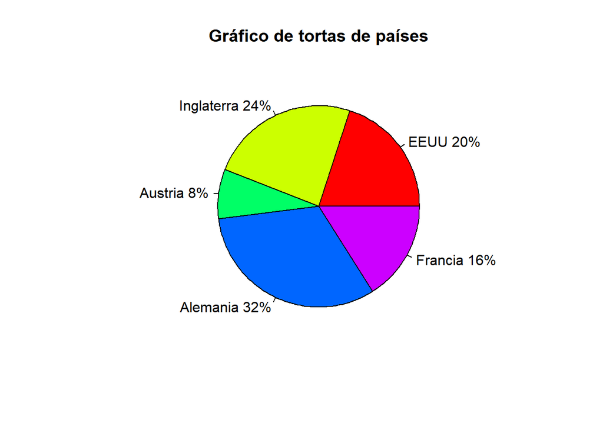

```r
# Estos son los datos a presentar
datos <- c(10, 12, 4, 16, 8)

# Estas son las etiquetas a presentar en cada porción de la torta
paises <- c("EEUU", "Inglaterra", "Austria", "Alemania", "Francia")

# Calculamos los porcentajes de cada porción
porcentajes <- round(datos / sum(datos) * 100)

# Ahora le pegamos a los nombres de los países, los porcentajes
etiqs <- paste(paises, porcentajes)
etiqs <- paste(etiqs, "%", sep = "")  # Le agregamos % a las etiquetas

pie(datos, labels = etiqs, col = rainbow(5), main = "Gráfico de tortas de países")
```

## Gráfico de Puntos

Presenta los datos de una muestra al representar cada dato con un punto ubicado a lo largo de una escala que puede ser horizontal o vertical. La frecuencia de los valores se representa a lo largo de la otra escala.

Por ejemplo, a continuación se toma la muestra de 19 calificaciones de un examen.

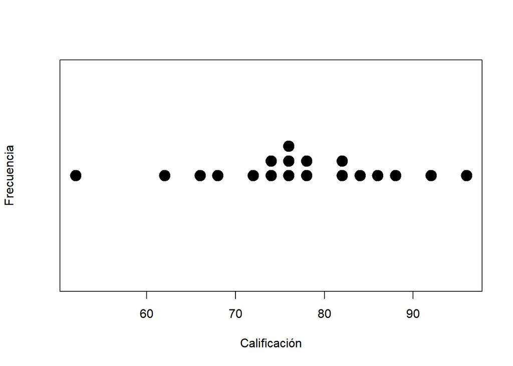

```r
calificaciones <- c(76, 74, 82, 96, 66, 76, 78, 72, 52, 68,
                    86, 84, 62, 76, 78, 92, 82, 74, 88)
stripchart(calificaciones, method = "stack", cex = 3, pch = 20,
           xlab = "Calificación", ylab = "Frecuencia")
```

Observe la forma en la que se “agrupan” los datos de la figura: están concentrados cerca del centro y más dispersados cerca de los extremos.

La presentación de una gráfica de puntos es una técnica que conviene usar cuando se empiezan a analizar los datos. Produce una imagen de los datos que los clasifica en orden numérico.